# Categorical Data

Yuanting Lu

08/29/2022

### Load Data

The first data set that we are going to examine is a simulated data set[^1] containing information of a large number of credit card holders. Read the data set from the web.

```r
credit <- read.csv('https://albums.yuanting.lu/sta126/22fa/credit.csv')
```

### Data Set Overview

1. How large is this data set?

```r
dim(credit) # The dimension (rows by columns) of the data set
```

2. What are the variables (columns) in the data set?

```r
names(credit)
```

3. Which of the variables are **categorical**? Which ones are numerical? We can take a peek of the data set by viewing its first a few rows (e.g., first 10 rows).

```r
head(credit, 10) # The head function shows the first a few rows of the data set.
```

### Graphs

1. Create a **frequency table** for a variable.[^2]

```r
table(credit$Student)
```

To convert the frequency table to a **relative frequency table**, we can divide the numbers in the table by the total number of customers in the data set. If you remember the total number of customers is 400, do `table(credit$Student) / 400`. Otherwise, we can use the length function to calculate the total so that we do `table(credit$Student) / length(credit$Student)`.

2. Create a **pie chart**.

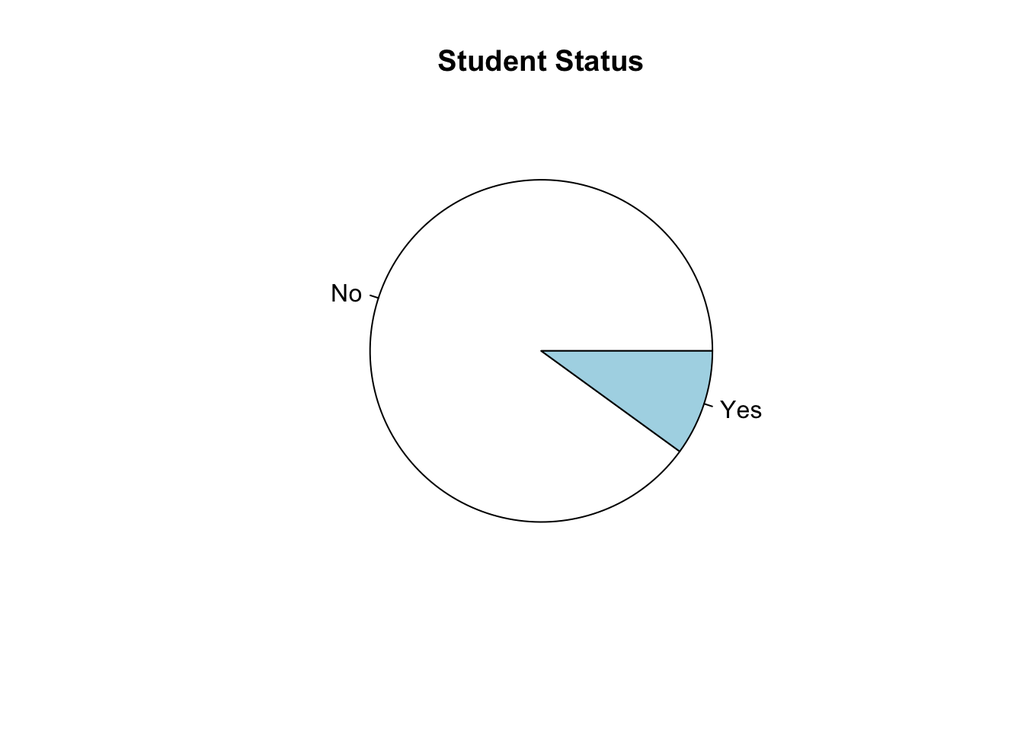

```r
freq <- table(credit$Student)
pie(freq, main = "Student Status")
```

- The code is equivalent to `pie(table(credit$Sstudent))`.
- The arrow sign (<-) in the first line of this code chunk deposits contents on the right-hand side of the arrow (i.e., the student status frequency table) to *R* variable on the left-hand side of the arrow (i.e., `freq`), so that from now on if we need the frequency table, we simply call `freq` instead of typing `table(credit$Student)` over and over again.
- The option main = “Student Status” adds a title to the graph.
3. Create a **bargraph**. We have already assigned `freq` to be the frequency table in the previous code chunk, so we can continue using it.

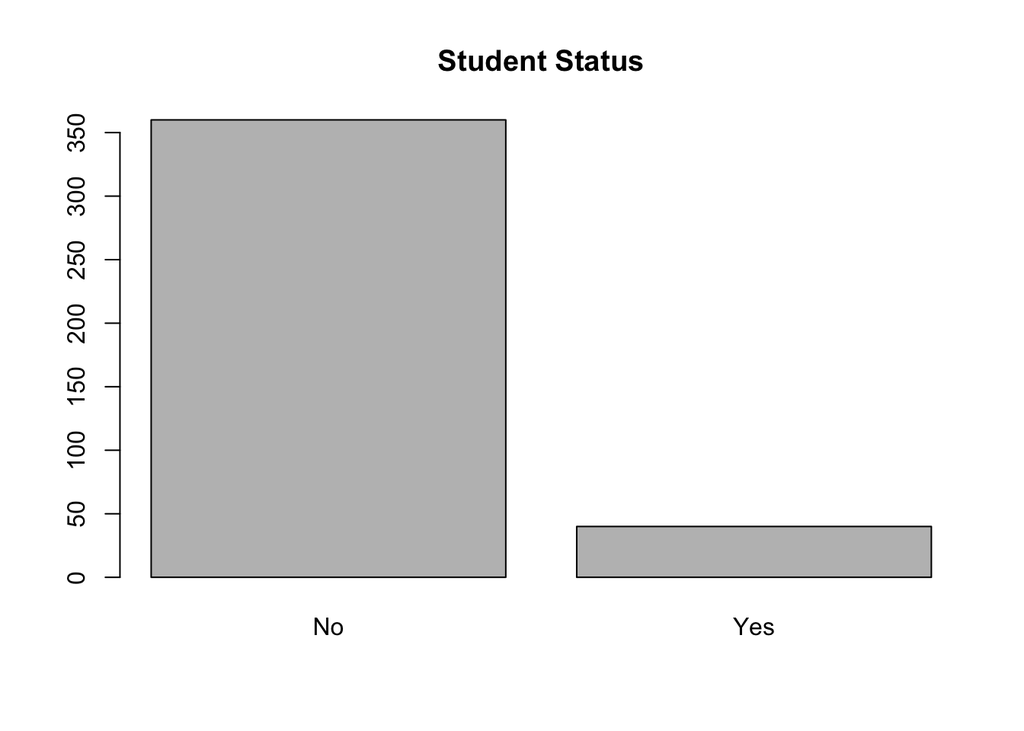

```r
barplot(freq, main = "Student Status")
```

**Practice:** Make the y-axis display relative frequency.

### [Plus] Graphic Skills +

- Customized colors.
  - The col = c(“lightblue”, “lightcoral”) option provides two colors to the graph.
  - The c function combines its arguments (e.g., “lightblue”, “lightcoral”) and creates a list.
- Customized group tags.
  - The labels option allows us to change the group tags in a pie chart.
  - The names option allows us to change the group tags in a bar graph.
- Customize text labels on the y-axis.
  - The ylab option allows us to change the text label on the y-axis.
- Use lines to shade bars and slices.
  - The density option provides the density of line segments to each bar or slice.
  - The angle option sets the angles of the line segments (in degrees).

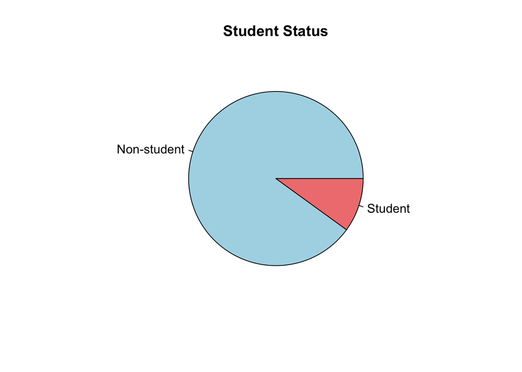

```r
freq <- table(credit$Student) / length(credit$Student)
pie(freq,
    col = c("lightblue", "lightcoral"),
    labels = c("Non-student", "Student"),
    main = "Student Status")
```

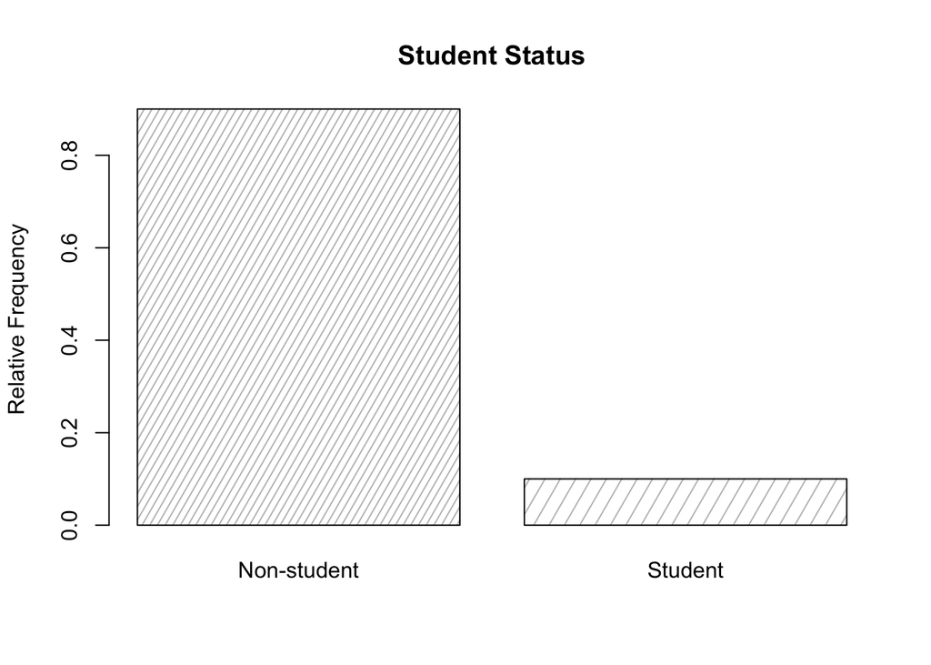

```r
barplot(freq,
        density = c(20, 10),
        angle = 60,
        names = c("Non-student", "Student"),
        ylab = "Relative Frequency",
        main = "Student Status")
```

[^1]: Gareth James, Daniela Witten, Trevor Hastie, Robert Tibshirani. (2013). *An introduction to statistical learning : with applications in R*. New York: Springer.
[^2]: `summary(credit$Student)` also works. The summary and table function are equivalent for categorical variables.